# SQ 026

## Shared Qs (026)

#### Question

1. The area of a triangle equals half the product of base times height.
   $$A_{\triangle}=\frac{bh}{2}$$

   This still works with obtuse triangles.

   Based on the formula above, and by using some trigonometry, **find the area** (in cm$^2$) of the triangle below, where $a=5.5$ cm and $b=7.2$ cm and $\gamma=\frac{3\pi}{5}$ radians.

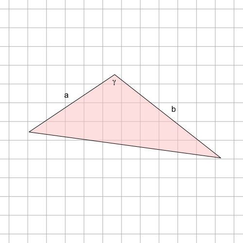

   The tolerance is $\pm0.1$ cm$^2$.

#### Solution

#### Question

2. The area of a triangle equals half the product of base times height.
   $$A_{\triangle}=\frac{bh}{2}$$

   This still works with obtuse triangles.

   Based on the formula above, and by using some trigonometry, **find the area** (in cm$^2$) of the triangle below, where $a=3.6$ cm and $b=5$ cm and $\gamma=\frac{2\pi}{5}$ radians.

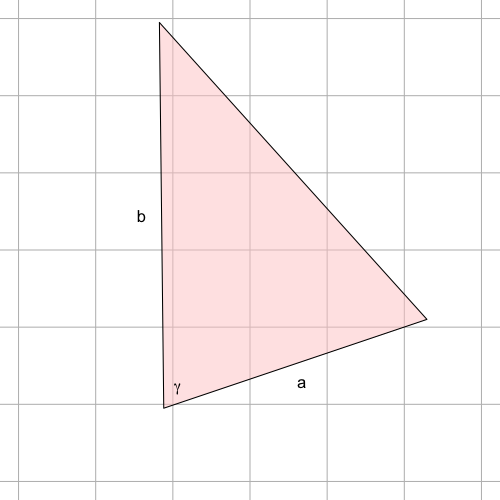

   The tolerance is $\pm0.1$ cm$^2$.

#### Solution

#### Question

3. The area of a triangle equals half the product of base times height.
   $$A_{\triangle}=\frac{bh}{2}$$

   This still works with obtuse triangles.

   Based on the formula above, and by using some trigonometry, **find the area** (in cm$^2$) of the triangle below, where $a=5.4$ cm and $b=3$ cm and $\gamma=\frac{9\pi}{13}$ radians.

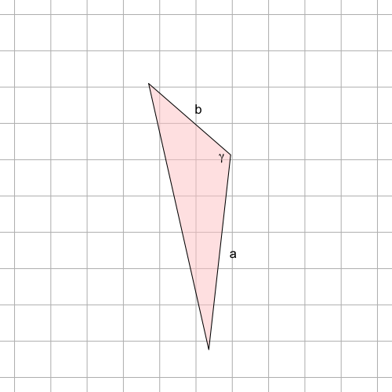

   The tolerance is $\pm0.1$ cm$^2$.

#### Solution

#### Question

4. The area of a triangle equals half the product of base times height.
   $$A_{\triangle}=\frac{bh}{2}$$

   This still works with obtuse triangles.

   Based on the formula above, and by using some trigonometry, **find the area** (in cm$^2$) of the triangle below, where $a=6.4$ cm and $b=2.9$ cm and $\gamma=\frac{8\pi}{13}$ radians.

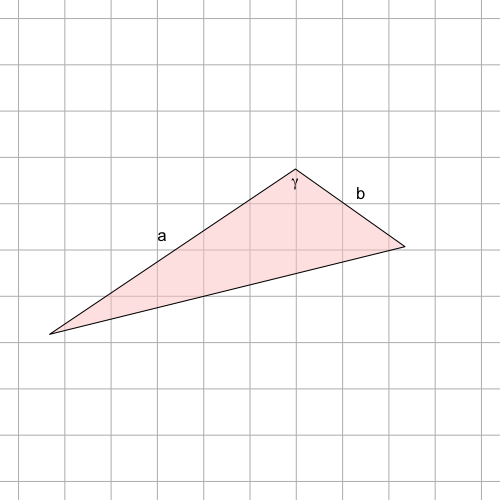

   The tolerance is $\pm0.1$ cm$^2$.

#### Solution

#### Question

5. The **[law of sines](https://en.wikipedia.org/wiki/Law_of_sines)** states that for any triangle with sides $a$, $b$, and $c$ — and with opposing angle measures $\alpha$, $\beta$, and $\gamma$ — all three quotients of length over sine are equivalent. Also, each quotient equals the diameter ($D$) of the circumcircle.

   $$\frac{a}{\sin(\alpha)} ~=~ \frac{b}{\sin(\beta)} ~=~ \frac{c}{\sin(\gamma)} ~=~ D$$

   Consider the triangle below with length $a=6.5$ cm and angle meansures $\alpha=\frac{5\pi}{47}$ and $\beta=\frac{14\pi}{47}$ and $\gamma=\frac{28\pi}{47}$ (radians).

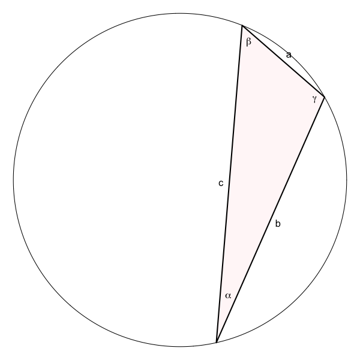

   **Find the length**, in cm, of side $c$. The tolerance is $\pm 0.1$ cm.

#### Solution

#### Question

6. The **[law of sines](https://en.wikipedia.org/wiki/Law_of_sines)** states that for any triangle with sides $a$, $b$, and $c$ — and with opposing angle measures $\alpha$, $\beta$, and $\gamma$ — all three quotients of length over sine are equivalent. Also, each quotient equals the diameter ($D$) of the circumcircle.

   $$\frac{a}{\sin(\alpha)} ~=~ \frac{b}{\sin(\beta)} ~=~ \frac{c}{\sin(\gamma)} ~=~ D$$

   Consider the triangle below with length $a=5.2$ cm and angle meansures $\alpha=\frac{9\pi}{43}$ and $\beta=\frac{29\pi}{43}$ and $\gamma=\frac{5\pi}{43}$ (radians).

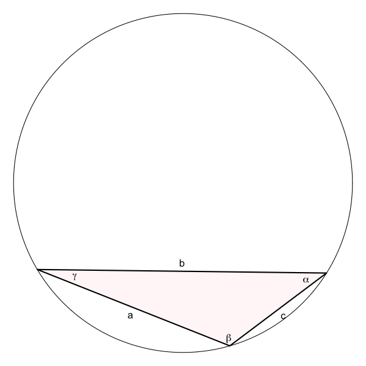

   **Find the length**, in cm, of side $c$. The tolerance is $\pm 0.1$ cm.

#### Solution

#### Question

7. The **[law of sines](https://en.wikipedia.org/wiki/Law_of_sines)** states that for any triangle with sides $a$, $b$, and $c$ — and with opposing angle measures $\alpha$, $\beta$, and $\gamma$ — all three quotients of length over sine are equivalent. Also, each quotient equals the diameter ($D$) of the circumcircle.

   $$\frac{a}{\sin(\alpha)} ~=~ \frac{b}{\sin(\beta)} ~=~ \frac{c}{\sin(\gamma)} ~=~ D$$

   Consider the triangle below with length $a=3.1$ cm and angle meansures $\alpha=\frac{12\pi}{41}$ and $\beta=\frac{15\pi}{41}$ and $\gamma=\frac{14\pi}{41}$ (radians).

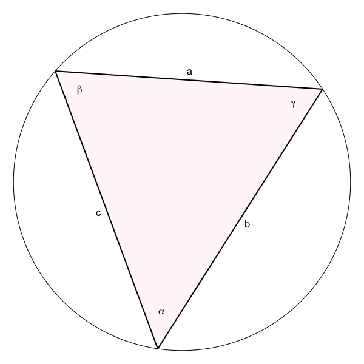

   **Find the length**, in cm, of side $b$. The tolerance is $\pm 0.1$ cm.

#### Solution

#### Question

8. The **[law of sines](https://en.wikipedia.org/wiki/Law_of_sines)** states that for any triangle with sides $a$, $b$, and $c$ — and with opposing angle measures $\alpha$, $\beta$, and $\gamma$ — all three quotients of length over sine are equivalent. Also, each quotient equals the diameter ($D$) of the circumcircle.

   $$\frac{a}{\sin(\alpha)} ~=~ \frac{b}{\sin(\beta)} ~=~ \frac{c}{\sin(\gamma)} ~=~ D$$

   Consider the triangle below with length $c=9$ cm and angle meansures $\alpha=\frac{11\pi}{73}$ and $\beta=\frac{44\pi}{73}$ and $\gamma=\frac{18\pi}{73}$ (radians).

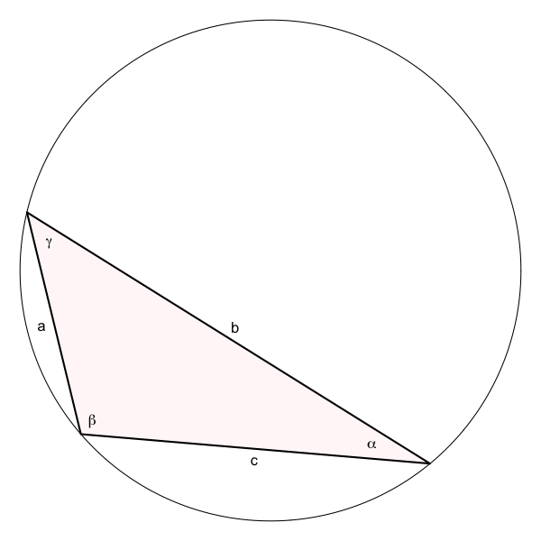

   **Find the length**, in cm, of side $b$. The tolerance is $\pm 0.1$ cm.

#### Solution

#### Question

9. This question is about the [ambiguous case](https://en.wikipedia.org/wiki/Law_of_sines#The_ambiguous_case_of_triangle_solution) encountered when using law of sines to find angles of triangles.

   Consider the triangle(s) with $\alpha=\frac{7\pi}{47}$ and $a=3.2$ and $c=4.8$. Notice there are two possible triangles with these attributes.

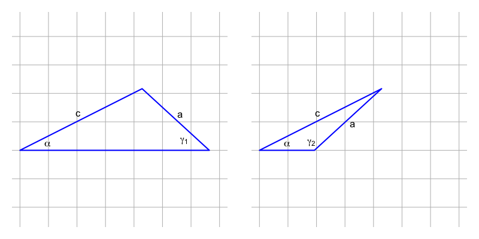

   The law of sines promises:

   $$\frac{\sin(\alpha)}{a} = \frac{\sin(\gamma_1)}{c}$$

   and

   $$\frac{\sin(\alpha)}{a} = \frac{\sin(\gamma_2)}{c}$$

   Find $\gamma_1$ and $\gamma_2$.
   - $\gamma_1 =$
   - $\gamma_2 =$

#### Solution

#### Question

10. This question is about the [ambiguous case](https://en.wikipedia.org/wiki/Law_of_sines#The_ambiguous_case_of_triangle_solution) encountered when using law of sines to find angles of triangles.

    Consider the triangle(s) with $\alpha=\frac{3\pi}{13}$ and $a=2.5$ and $c=3.4$. Notice there are two possible triangles with these attributes.

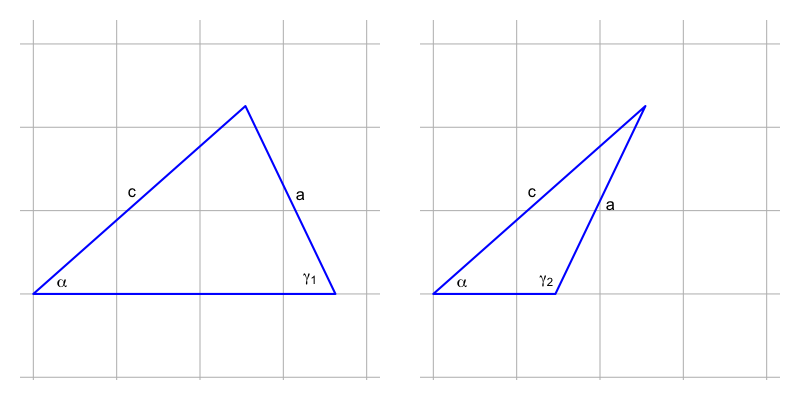

    The law of sines promises:

    $$\frac{\sin(\alpha)}{a} = \frac{\sin(\gamma_1)}{c}$$

    and

    $$\frac{\sin(\alpha)}{a} = \frac{\sin(\gamma_2)}{c}$$

    Find $\gamma_1$ and $\gamma_2$.
    - $\gamma_1 =$
    - $\gamma_2 =$

#### Solution

#### Question

11. This question is about the [ambiguous case](https://en.wikipedia.org/wiki/Law_of_sines#The_ambiguous_case_of_triangle_solution) encountered when using law of sines to find angles of triangles.

    Consider the triangle(s) with $\alpha=\frac{17\pi}{67}$ and $a=2.8$ and $c=3.7$. Notice there are two possible triangles with these attributes.

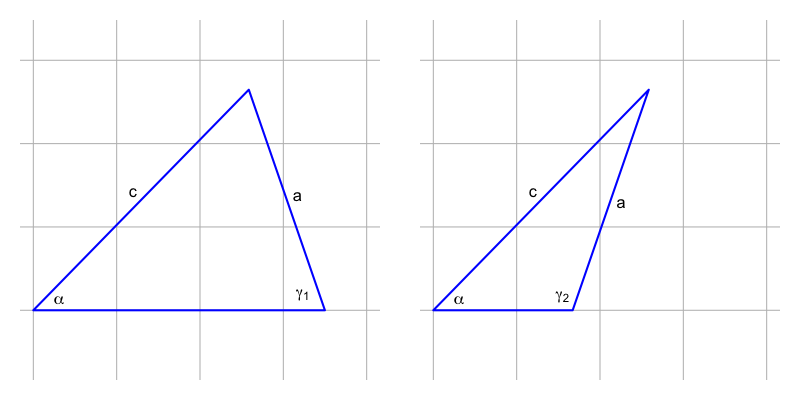

    The law of sines promises:

    $$\frac{\sin(\alpha)}{a} = \frac{\sin(\gamma_1)}{c}$$

    and

    $$\frac{\sin(\alpha)}{a} = \frac{\sin(\gamma_2)}{c}$$

    Find $\gamma_1$ and $\gamma_2$.
    - $\gamma_1 =$
    - $\gamma_2 =$

#### Solution

#### Question

12. This question is about the [ambiguous case](https://en.wikipedia.org/wiki/Law_of_sines#The_ambiguous_case_of_triangle_solution) encountered when using law of sines to find angles of triangles.

    Consider the triangle(s) with $\alpha=\frac{4\pi}{17}$ and $a=5.2$ and $c=6.7$. Notice there are two possible triangles with these attributes.

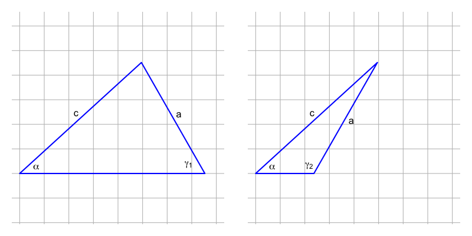

    The law of sines promises:

    $$\frac{\sin(\alpha)}{a} = \frac{\sin(\gamma_1)}{c}$$

    and

    $$\frac{\sin(\alpha)}{a} = \frac{\sin(\gamma_2)}{c}$$

    Find $\gamma_1$ and $\gamma_2$.
    - $\gamma_1 =$
    - $\gamma_2 =$

#### Solution

#### Question

13. The [law of cosines](https://en.wikipedia.org/wiki/Law_of_cosines) is a correction to [Pythagorean Theorem](https://en.wikipedia.org/wiki/Pythagorean_theorem) that is accurate for ALL triangles (not just right triangles).

    $$a^2 = b^2+c^2-2bc\cos(\alpha)$$
    $$b^2 = a^2+c^2-2ac\cos(\beta)$$
    $$c^2 = a^2+b^2-2ab\cos(\gamma)$$

    where angles with measures $\alpha$, $\beta$, and $\gamma$ are opposing sides with lengths $a$, $b$, and $c$ respectively.

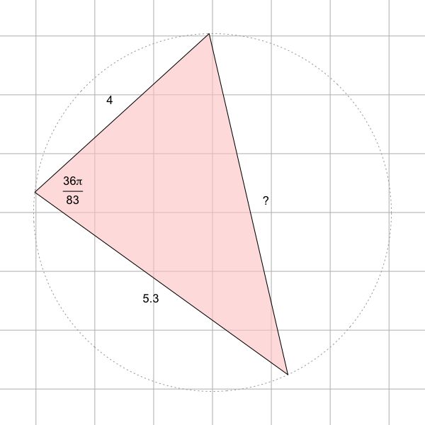

    In a triangle, two sides have lengths 5.3 and 4 with an included angle with measure $\frac{36\pi}{83}$ radians.

    **Find the length** labelled “?”. The tolerance is $\pm 0.01$.

#### Solution

#### Question

14. The [law of cosines](https://en.wikipedia.org/wiki/Law_of_cosines) is a correction to [Pythagorean Theorem](https://en.wikipedia.org/wiki/Pythagorean_theorem) that is accurate for ALL triangles (not just right triangles).

    $$a^2 = b^2+c^2-2bc\cos(\alpha)$$
    $$b^2 = a^2+c^2-2ac\cos(\beta)$$
    $$c^2 = a^2+b^2-2ab\cos(\gamma)$$

    where angles with measures $\alpha$, $\beta$, and $\gamma$ are opposing sides with lengths $a$, $b$, and $c$ respectively.

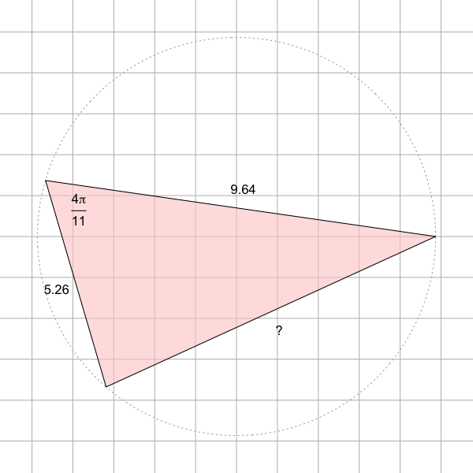

    In a triangle, two sides have lengths 5.26 and 9.64 with an included angle with measure $\frac{4\pi}{11}$ radians.

    **Find the length** labelled “?”. The tolerance is $\pm 0.01$.

#### Solution

#### Question

15. The [law of cosines](https://en.wikipedia.org/wiki/Law_of_cosines) is a correction to [Pythagorean Theorem](https://en.wikipedia.org/wiki/Pythagorean_theorem) that is accurate for ALL triangles (not just right triangles).

    $$a^2 = b^2+c^2-2bc\cos(\alpha)$$
    $$b^2 = a^2+c^2-2ac\cos(\beta)$$
    $$c^2 = a^2+b^2-2ab\cos(\gamma)$$

    where angles with measures $\alpha$, $\beta$, and $\gamma$ are opposing sides with lengths $a$, $b$, and $c$ respectively.

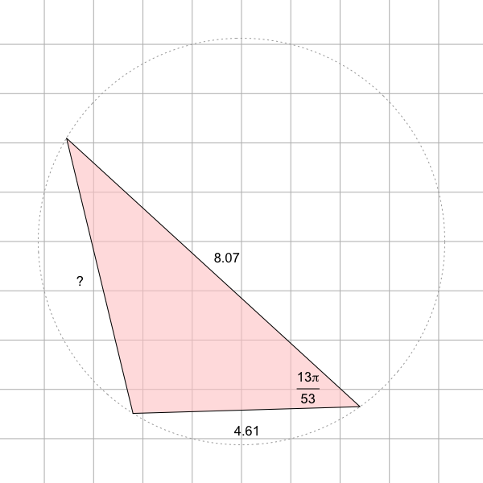

    In a triangle, two sides have lengths 4.61 and 8.07 with an included angle with measure $\frac{13\pi}{53}$ radians.

    **Find the length** labelled “?”. The tolerance is $\pm 0.01$.

#### Solution

#### Question

16. The [law of cosines](https://en.wikipedia.org/wiki/Law_of_cosines) is a correction to [Pythagorean Theorem](https://en.wikipedia.org/wiki/Pythagorean_theorem) that is accurate for ALL triangles (not just right triangles).

    $$a^2 = b^2+c^2-2bc\cos(\alpha)$$
    $$b^2 = a^2+c^2-2ac\cos(\beta)$$
    $$c^2 = a^2+b^2-2ab\cos(\gamma)$$

    where angles with measures $\alpha$, $\beta$, and $\gamma$ are opposing sides with lengths $a$, $b$, and $c$ respectively.

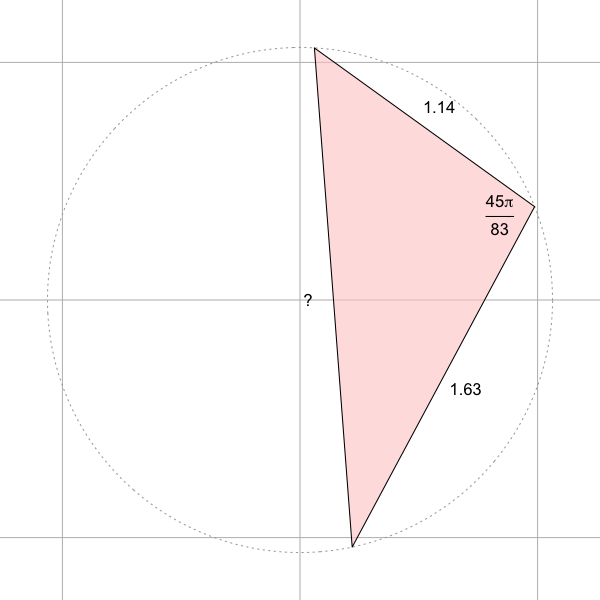

    In a triangle, two sides have lengths 1.63 and 1.14 with an included angle with measure $\frac{45\pi}{83}$ radians.

    **Find the length** labelled “?”. The tolerance is $\pm 0.01$.

#### Solution

#### Question

17. The [law of cosines](https://en.wikipedia.org/wiki/Law_of_cosines) is a correction to [Pythagorean Theorem](https://en.wikipedia.org/wiki/Pythagorean_theorem) that is accurate for ALL triangles (not just right triangles).

    $$a^2 = b^2+c^2-2bc\cos(\alpha)$$
    $$b^2 = a^2+c^2-2ac\cos(\beta)$$
    $$c^2 = a^2+b^2-2ab\cos(\gamma)$$

    where angles with measures $\alpha$, $\beta$, and $\gamma$ are opposite the sides with lengths $a$, $b$, and $c$ respectively.

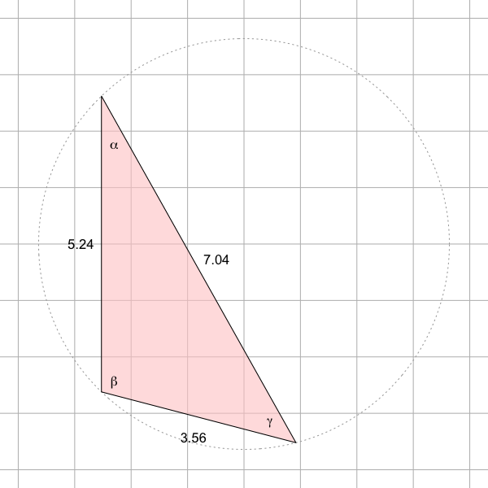

    The lengths of a triangle are shown above in the diagram.

    **Find the angle measure** $\gamma$. The tolerance is $\pm 0.01$ radians.

#### Solution

#### Question

18. The [law of cosines](https://en.wikipedia.org/wiki/Law_of_cosines) is a correction to [Pythagorean Theorem](https://en.wikipedia.org/wiki/Pythagorean_theorem) that is accurate for ALL triangles (not just right triangles).

    $$a^2 = b^2+c^2-2bc\cos(\alpha)$$
    $$b^2 = a^2+c^2-2ac\cos(\beta)$$
    $$c^2 = a^2+b^2-2ab\cos(\gamma)$$

    where angles with measures $\alpha$, $\beta$, and $\gamma$ are opposite the sides with lengths $a$, $b$, and $c$ respectively.

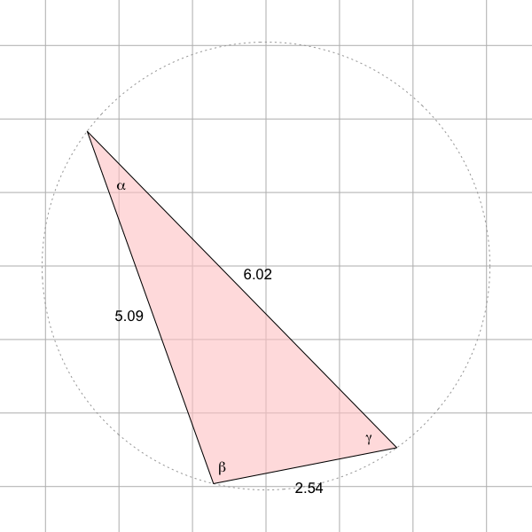

    The lengths of a triangle are shown above in the diagram.

    **Find the angle measure** $\beta$. The tolerance is $\pm 0.01$ radians.

#### Solution

#### Question

19. The [law of cosines](https://en.wikipedia.org/wiki/Law_of_cosines) is a correction to [Pythagorean Theorem](https://en.wikipedia.org/wiki/Pythagorean_theorem) that is accurate for ALL triangles (not just right triangles).

    $$a^2 = b^2+c^2-2bc\cos(\alpha)$$
    $$b^2 = a^2+c^2-2ac\cos(\beta)$$
    $$c^2 = a^2+b^2-2ab\cos(\gamma)$$

    where angles with measures $\alpha$, $\beta$, and $\gamma$ are opposite the sides with lengths $a$, $b$, and $c$ respectively.

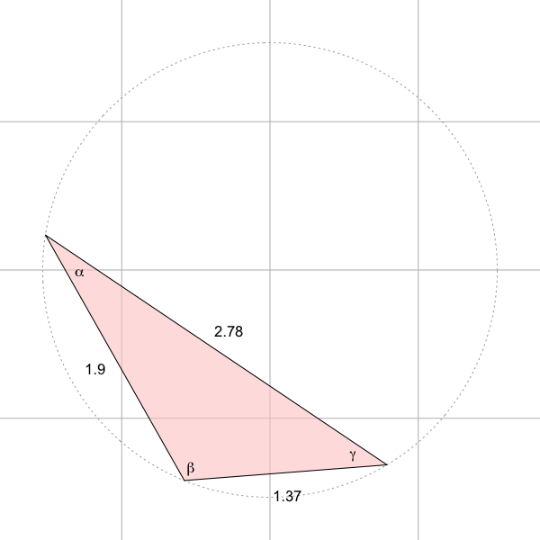

    The lengths of a triangle are shown above in the diagram.

    **Find the angle measure** $\beta$. The tolerance is $\pm 0.01$ radians.

#### Solution

#### Question

20. The [law of cosines](https://en.wikipedia.org/wiki/Law_of_cosines) is a correction to [Pythagorean Theorem](https://en.wikipedia.org/wiki/Pythagorean_theorem) that is accurate for ALL triangles (not just right triangles).

    $$a^2 = b^2+c^2-2bc\cos(\alpha)$$
    $$b^2 = a^2+c^2-2ac\cos(\beta)$$
    $$c^2 = a^2+b^2-2ab\cos(\gamma)$$

    where angles with measures $\alpha$, $\beta$, and $\gamma$ are opposite the sides with lengths $a$, $b$, and $c$ respectively.

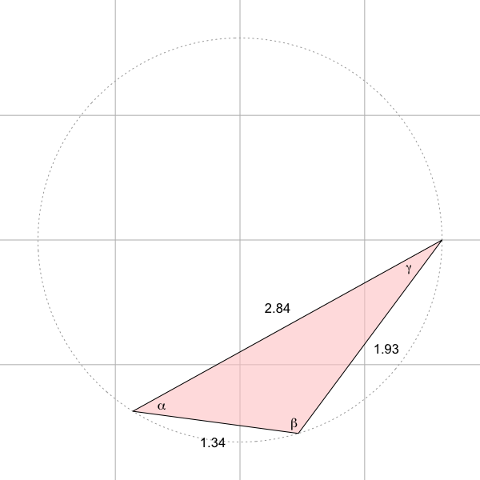

    The lengths of a triangle are shown above in the diagram.

    **Find the angle measure** $\alpha$. The tolerance is $\pm 0.01$ radians.

#### Solution

#### Question

21. Some equations are true for ANY substitutions of numbers for the variables (see [universal quantification](https://en.wikipedia.org/wiki/Universal_quantification)). Other equations are only true for SOME substitutions of numbers (see [existential quantification](https://en.wikipedia.org/wiki/Existential_quantification)).

    When an equation is true for ANY substitution, we call it an identity. If you want to be fancy, you might put a “[for all](https://en.wikipedia.org/wiki/Turned_A)” symbol nearby (e.g. $\forall x:~~ x^2=x\cdot x$), or use a triple equals ($\equiv$) to reinforce that an equation is an identity.

    An essential identity in trigonometry is the [angle sum identity](https://en.wikipedia.org/wiki/List_of_trigonometric_identities#Angle_sum_and_difference_identities). We already saw how to derive the ratios of $30-60-90$ and $45-45-90$ triangles, but the angle-sum identity (indirectly) allows us to find exact ratios for a LOT of other right triangles (to get as fine-grained as we want).

    The angle-sum and angle-difference identities are true for all values of $\alpha$ and $\beta$:

    $$\sin(\alpha+\beta) ~\equiv~ \sin(\alpha)\cos(\beta)+\cos(\alpha)\sin(\beta)$$
    $$\cos(\alpha+\beta) ~\equiv~ \cos(\alpha)\cos(\beta)-\sin(\alpha)\sin(\beta)$$
    $$\sin(\alpha-\beta) ~\equiv~ \sin(\alpha)\cos(\beta)-\cos(\alpha)\sin(\beta)$$
    $$\cos(\alpha-\beta) ~\equiv~ \cos(\alpha)\cos(\beta)+\sin(\alpha)\sin(\beta)$$

    I randomly chose values for $\alpha$ and $\beta$, which I am purposefully obscuring to try to get you to use the identites above. I will instead tell you some (approximate) trig ratios.

    $$\begin{align*}
    \sin(\alpha) &= 0.64 & \cos(\alpha) &= 0.76 \\
    \sin(\beta) &= 0.86 & \cos(\beta) &= -0.5
    \end{align*}$$

    Evaluate $\cos(\alpha-\beta)$ using the values above. The tolerance is $\pm 0.01$.

#### Solution

#### Question

22. Some equations are true for ANY substitutions of numbers for the variables (see [universal quantification](https://en.wikipedia.org/wiki/Universal_quantification)). Other equations are only true for SOME substitutions of numbers (see [existential quantification](https://en.wikipedia.org/wiki/Existential_quantification)).

    When an equation is true for ANY substitution, we call it an identity. If you want to be fancy, you might put a “[for all](https://en.wikipedia.org/wiki/Turned_A)” symbol nearby (e.g. $\forall x:~~ x^2=x\cdot x$), or use a triple equals ($\equiv$) to reinforce that an equation is an identity.

    An essential identity in trigonometry is the [angle sum identity](https://en.wikipedia.org/wiki/List_of_trigonometric_identities#Angle_sum_and_difference_identities). We already saw how to derive the ratios of $30-60-90$ and $45-45-90$ triangles, but the angle-sum identity (indirectly) allows us to find exact ratios for a LOT of other right triangles (to get as fine-grained as we want).

    The angle-sum and angle-difference identities are true for all values of $\alpha$ and $\beta$:

    $$\sin(\alpha+\beta) ~\equiv~ \sin(\alpha)\cos(\beta)+\cos(\alpha)\sin(\beta)$$
    $$\cos(\alpha+\beta) ~\equiv~ \cos(\alpha)\cos(\beta)-\sin(\alpha)\sin(\beta)$$
    $$\sin(\alpha-\beta) ~\equiv~ \sin(\alpha)\cos(\beta)-\cos(\alpha)\sin(\beta)$$
    $$\cos(\alpha-\beta) ~\equiv~ \cos(\alpha)\cos(\beta)+\sin(\alpha)\sin(\beta)$$

    I randomly chose values for $\alpha$ and $\beta$, which I am purposefully obscuring to try to get you to use the identites above. I will instead tell you some (approximate) trig ratios.

    $$\begin{align*}
    \sin(\alpha) &= 0.64 & \cos(\alpha) &= 0.76 \\
    \sin(\beta) &= 0.91 & \cos(\beta) &= -0.42
    \end{align*}$$

    Evaluate $\sin(\alpha+\beta)$ using the values above. The tolerance is $\pm 0.01$.

#### Solution

#### Question

23. Some equations are true for ANY substitutions of numbers for the variables (see [universal quantification](https://en.wikipedia.org/wiki/Universal_quantification)). Other equations are only true for SOME substitutions of numbers (see [existential quantification](https://en.wikipedia.org/wiki/Existential_quantification)).

    When an equation is true for ANY substitution, we call it an identity. If you want to be fancy, you might put a “[for all](https://en.wikipedia.org/wiki/Turned_A)” symbol nearby (e.g. $\forall x:~~ x^2=x\cdot x$), or use a triple equals ($\equiv$) to reinforce that an equation is an identity.

    An essential identity in trigonometry is the [angle sum identity](https://en.wikipedia.org/wiki/List_of_trigonometric_identities#Angle_sum_and_difference_identities). We already saw how to derive the ratios of $30-60-90$ and $45-45-90$ triangles, but the angle-sum identity (indirectly) allows us to find exact ratios for a LOT of other right triangles (to get as fine-grained as we want).

    The angle-sum and angle-difference identities are true for all values of $\alpha$ and $\beta$:

    $$\sin(\alpha+\beta) ~\equiv~ \sin(\alpha)\cos(\beta)+\cos(\alpha)\sin(\beta)$$
    $$\cos(\alpha+\beta) ~\equiv~ \cos(\alpha)\cos(\beta)-\sin(\alpha)\sin(\beta)$$
    $$\sin(\alpha-\beta) ~\equiv~ \sin(\alpha)\cos(\beta)-\cos(\alpha)\sin(\beta)$$
    $$\cos(\alpha-\beta) ~\equiv~ \cos(\alpha)\cos(\beta)+\sin(\alpha)\sin(\beta)$$

    I randomly chose values for $\alpha$ and $\beta$, which I am purposefully obscuring to try to get you to use the identites above. I will instead tell you some (approximate) trig ratios.

    $$\begin{align*}
    \sin(\alpha) &= 0.64 & \cos(\alpha) &= 0.76 \\
    \sin(\beta) &= 0.91 & \cos(\beta) &= -0.42
    \end{align*}$$

    Evaluate $\sin(\alpha+\beta)$ using the values above. The tolerance is $\pm 0.01$.

#### Solution

#### Question

24. Some equations are true for ANY substitutions of numbers for the variables (see [universal quantification](https://en.wikipedia.org/wiki/Universal_quantification)). Other equations are only true for SOME substitutions of numbers (see [existential quantification](https://en.wikipedia.org/wiki/Existential_quantification)).

    When an equation is true for ANY substitution, we call it an identity. If you want to be fancy, you might put a “[for all](https://en.wikipedia.org/wiki/Turned_A)” symbol nearby (e.g. $\forall x:~~ x^2=x\cdot x$), or use a triple equals ($\equiv$) to reinforce that an equation is an identity.

    An essential identity in trigonometry is the [angle sum identity](https://en.wikipedia.org/wiki/List_of_trigonometric_identities#Angle_sum_and_difference_identities). We already saw how to derive the ratios of $30-60-90$ and $45-45-90$ triangles, but the angle-sum identity (indirectly) allows us to find exact ratios for a LOT of other right triangles (to get as fine-grained as we want).

    The angle-sum and angle-difference identities are true for all values of $\alpha$ and $\beta$:

    $$\sin(\alpha+\beta) ~\equiv~ \sin(\alpha)\cos(\beta)+\cos(\alpha)\sin(\beta)$$
    $$\cos(\alpha+\beta) ~\equiv~ \cos(\alpha)\cos(\beta)-\sin(\alpha)\sin(\beta)$$
    $$\sin(\alpha-\beta) ~\equiv~ \sin(\alpha)\cos(\beta)-\cos(\alpha)\sin(\beta)$$
    $$\cos(\alpha-\beta) ~\equiv~ \cos(\alpha)\cos(\beta)+\sin(\alpha)\sin(\beta)$$

    I randomly chose values for $\alpha$ and $\beta$, which I am purposefully obscuring to try to get you to use the identites above. I will instead tell you some (approximate) trig ratios.

    $$\begin{align*}
    \sin(\alpha) &= 0.64 & \cos(\alpha) &= 0.76 \\
    \sin(\beta) &= 0.86 & \cos(\beta) &= -0.5
    \end{align*}$$

    Evaluate $\cos(\alpha-\beta)$ using the values above. The tolerance is $\pm 0.01$.

#### Solution

#### Question

25. In the diagram below, let $\alpha=0.354$ radians and $\beta=0.601$ radians. Find all the lengths (to the nearest thousandth) and angle measures $\theta$ and $\phi$. Use unrounded values for all intermediate calculations.

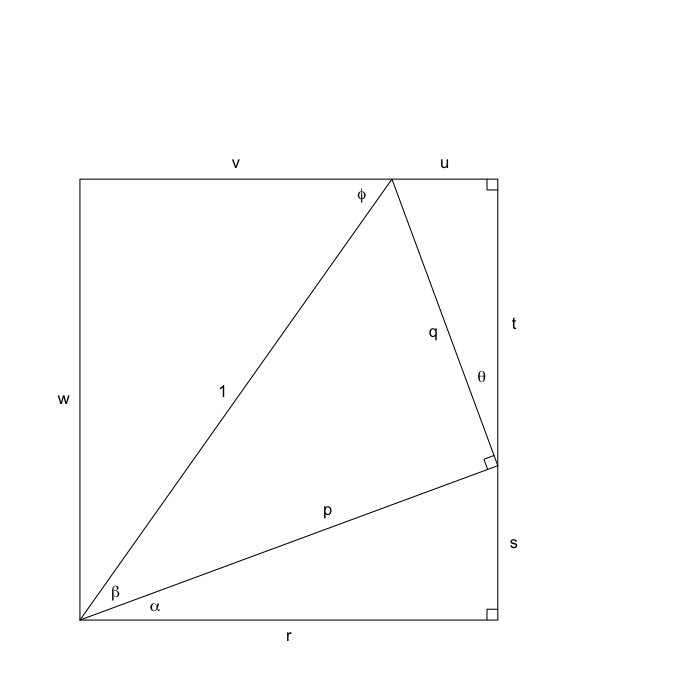

    - $p=$
    - $q=$
    - $r=$
    - $s=$
    - $\theta=$
    - $t=$
    - $u=$
    - $\phi=$
    - $v=$
    - $w=$

#### Solution

#### Question

26. In the diagram below, let $\alpha=0.663$ radians and $\beta=0.552$ radians. Find all the lengths (to the nearest thousandth) and angle measures $\theta$ and $\phi$. Use unrounded values for all intermediate calculations.

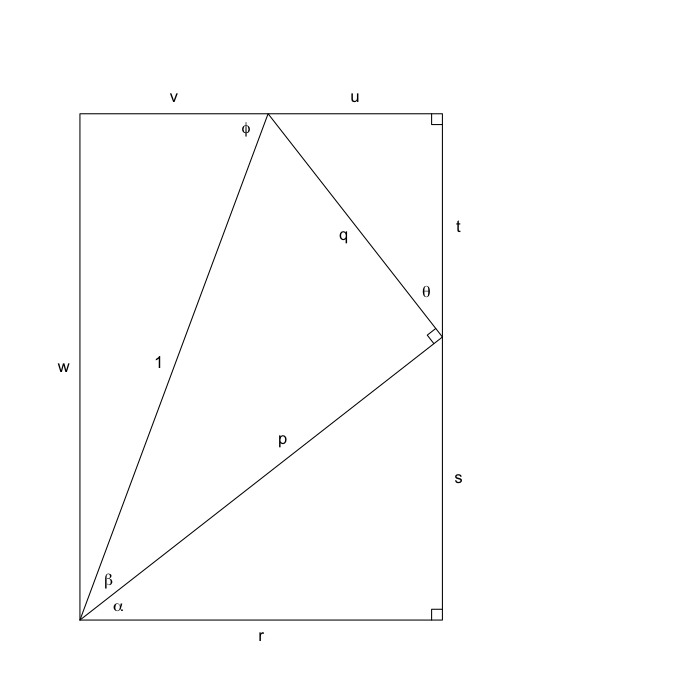

    - $p=$
    - $q=$
    - $r=$
    - $s=$
    - $\theta=$
    - $t=$
    - $u=$
    - $\phi=$
    - $v=$
    - $w=$

#### Solution

#### Question

27. In the diagram below, let $\alpha=0.401$ radians and $\beta=0.537$ radians. Find all the lengths (to the nearest thousandth) and angle measures $\theta$ and $\phi$. Use unrounded values for all intermediate calculations.

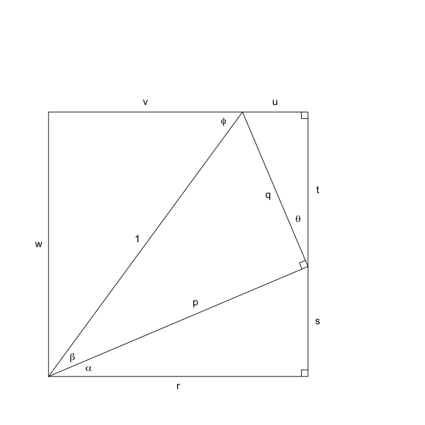

    - $p=$
    - $q=$
    - $r=$
    - $s=$
    - $\theta=$
    - $t=$
    - $u=$
    - $\phi=$
    - $v=$
    - $w=$

#### Solution

#### Question

28. In the diagram below, let $\alpha=0.337$ radians and $\beta=0.525$ radians. Find all the lengths (to the nearest thousandth) and angle measures $\theta$ and $\phi$. Use unrounded values for all intermediate calculations.

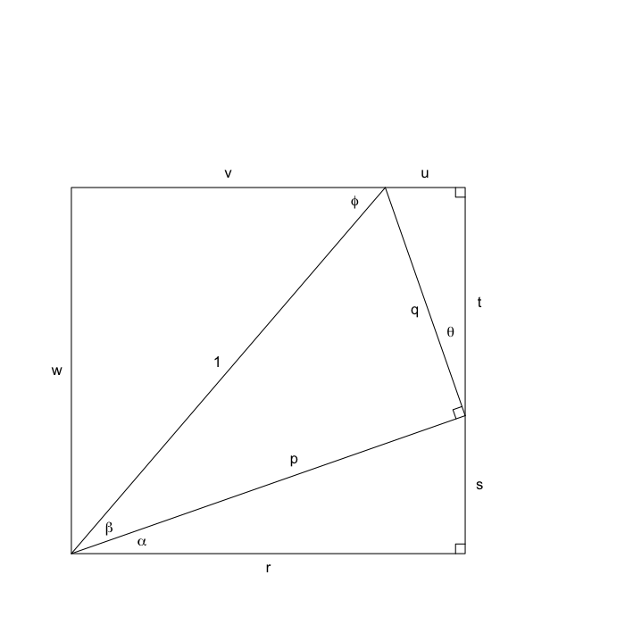

    - $p=$
    - $q=$
    - $r=$
    - $s=$
    - $\theta=$
    - $t=$
    - $u=$
    - $\phi=$
    - $v=$
    - $w=$

#### Solution

#### Question

29. In terms of $a$ and $b$, express all the lengths and other angle measures ($\theta$ and $\phi$).

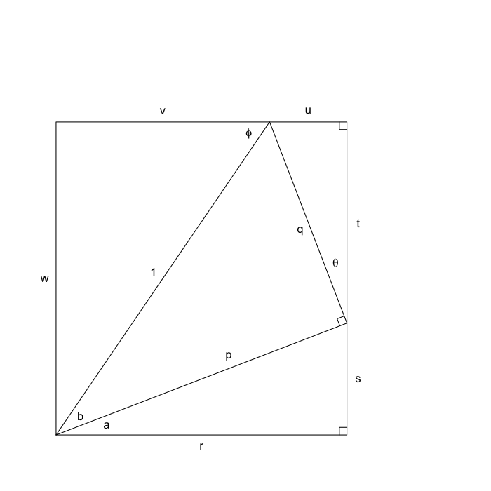

    - $p=$
    - $q=$
    - $r=$
    - $s=$
    - $\theta=$
    - $t=$
    - $u=$
    - $\phi=$
    - $v=$
    - $w=$

#### Solution

#### Question

30. In terms of $a$ and $b$, express all the lengths and other angle measures ($\theta$ and $\phi$).

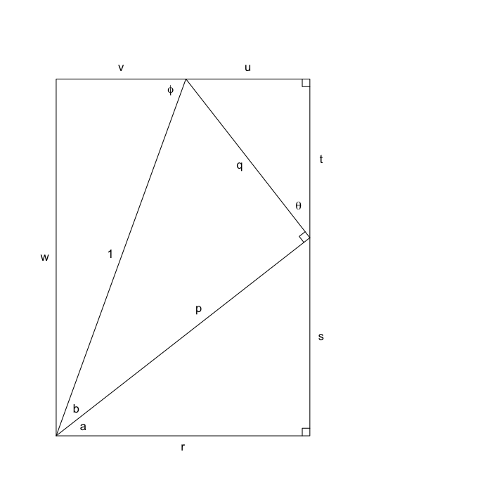

    - $p=$
    - $q=$
    - $r=$
    - $s=$
    - $\theta=$
    - $t=$
    - $u=$
    - $\phi=$
    - $v=$
    - $w=$

#### Solution

#### Question

31. In terms of $a$ and $b$, express all the lengths and other angle measures ($\theta$ and $\phi$).

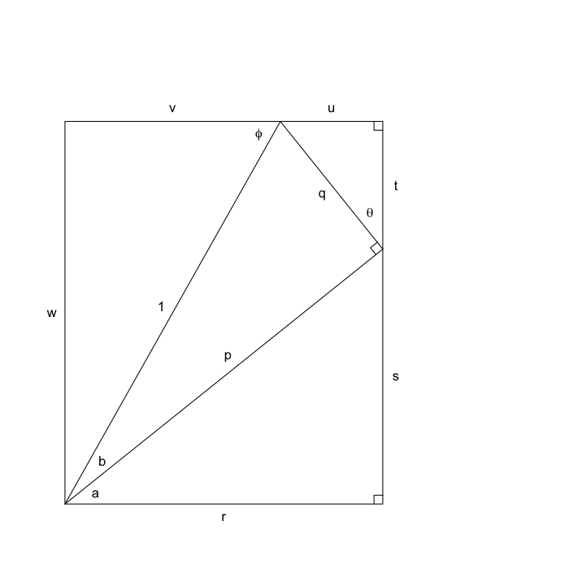

    - $p=$
    - $q=$
    - $r=$
    - $s=$
    - $\theta=$
    - $t=$
    - $u=$
    - $\phi=$
    - $v=$
    - $w=$

#### Solution

#### Question

32. In terms of $a$ and $b$, express all the lengths and other angle measures ($\theta$ and $\phi$).

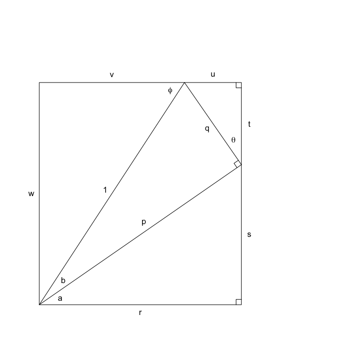

    - $p=$
    - $q=$
    - $r=$
    - $s=$
    - $\theta=$
    - $t=$
    - $u=$
    - $\phi=$
    - $v=$
    - $w=$

#### Solution

#### Question

33. Match the animations to the equations.

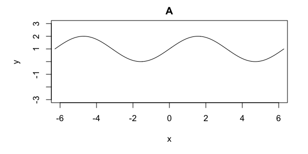

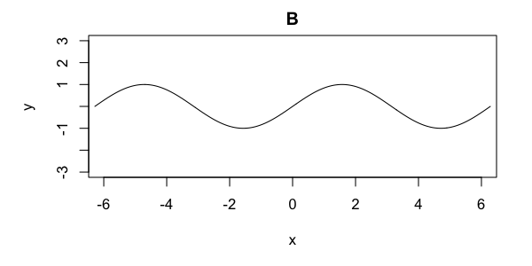

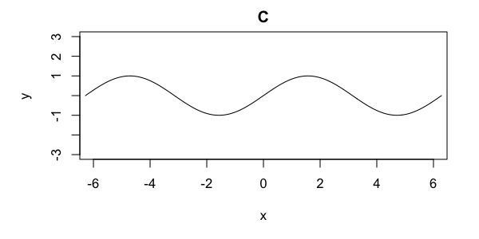

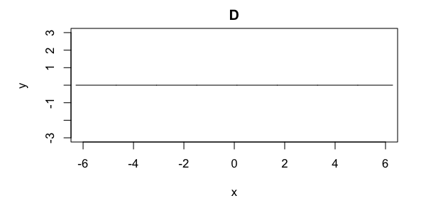

    Match each equation to its animation. In the animations, $t$ goes from 0 to $2\pi$.
    - $y=\sin(x)+\cos(t)~\to$
    - $y=\sin(x\cdot t)~\to$
    - $y=\frac{\sin(x-t)+\sin(x+t)}{2}~\to$
    - $y=\sin(x+t)~\to$
    - $y=\sin(x)\cdot \cos(t)~\to$
    - $y=\sin(x)\cos(t)+\cos(x)\sin(t)~\to$

#### Solution

#### Question

34. Match the animations to the equations.

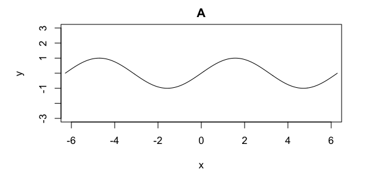

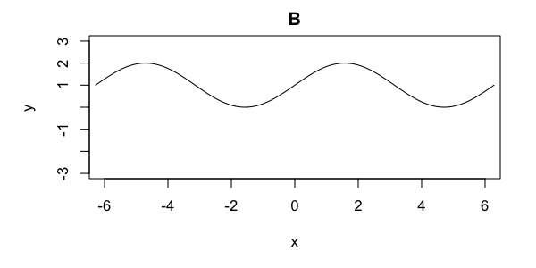

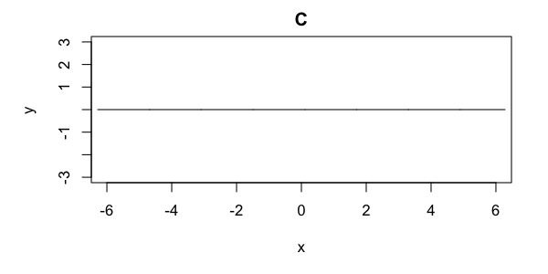

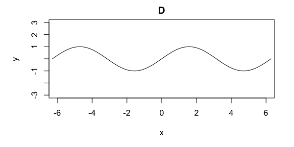

    Match each equation to its animation. In the animations, $t$ goes from 0 to $2\pi$.
    - $y=\sin(x+t)~\to$
    - $y=\sin(x)+\cos(t)~\to$
    - $y=\sin(x)\cos(t)+\cos(x)\sin(t)~\to$
    - $y=\sin(x)\cdot \cos(t)~\to$
    - $y=\sin(x\cdot t)~\to$
    - $y=\frac{\sin(x-t)+\sin(x+t)}{2}~\to$

#### Solution

#### Question

35. Match the animations to the equations.

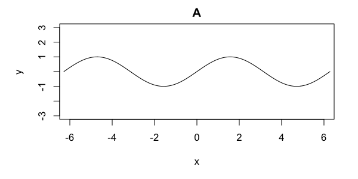

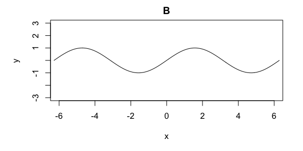

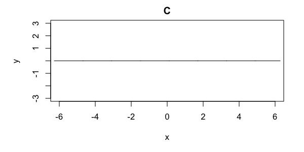

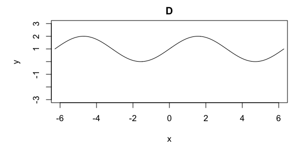

    Match each equation to its animation. In the animations, $t$ goes from 0 to $2\pi$.
    - $y=\sin(x)+\cos(t)~\to$
    - $y=\sin(x)\cdot \cos(t)~\to$
    - $y=\sin(x\cdot t)~\to$
    - $y=\sin(x+t)~\to$
    - $y=\sin(x)\cos(t)+\cos(x)\sin(t)~\to$
    - $y=\frac{\sin(x-t)+\sin(x+t)}{2}~\to$

#### Question

36. Match the animations to the equations.

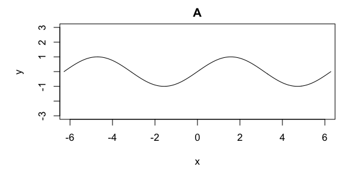

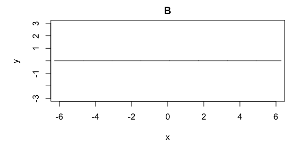

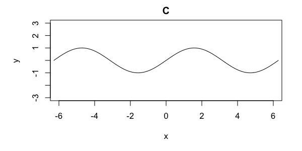

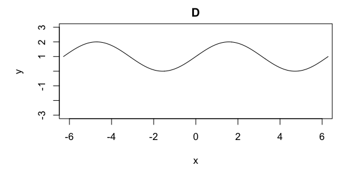

    Match each equation to its animation. In the animations, $t$ goes from 0 to $2\pi$.
    - $y=\frac{\sin(x-t)+\sin(x+t)}{2}~\to$
    - $y=\sin(x+t)~\to$
    - $y=\sin(x)\cdot \cos(t)~\to$
    - $y=\sin(x)\cos(t)+\cos(x)\sin(t)~\to$
    - $y=\sin(x\cdot t)~\to$
    - $y=\sin(x)+\cos(t)~\to$

#### Question

37. A taught string, fixed at 2 ends, produces a harmonic series based on the [standing waves](https://en.wikipedia.org/wiki/Standing_wave#Standing_wave_on_a_string_with_two_fixed_ends) that [resonate](https://en.wikipedia.org/wiki/Resonance). Other frequencies fizzle out quickly because they are not resonant with the system.

    We will simulate a string vibrating at its [fundamental frequency](https://en.wikipedia.org/wiki/Fundamental_frequency) and two of its [overtones](https://en.wikipedia.org/wiki/Overtone). We will also pay attention to the phase of each partial.

    Let’s assume the string is of length $\pi$ meters and the period of the fundamental is $2\pi$ seconds (so $t$ goes from 0 to $2\pi$).

    $$y_1 = A_1 \sin(x)\cdot \sin(t+\phi_1)$$

    The next two overtones have similar equations.

    $$y_2 = A_2 \sin(2x)\cdot \sin(2t+\phi_2)$$

    $$y_3 = A_3 \sin(3x)\cdot \sin(3t+\phi_3)$$

    When all three modes of oscillation occur simultaneously, the result is a superposition of waves.

    $$y = y_1+y_2+y_3$$

    Determine which set of parameters generates the animation below (when viewing the superposition).

### Parameter set 1

    $$\begin{align*}
    A_1 &= 0.12 & \phi_1 &= 2.75 \\
    A_2 &= 0.66 & \phi_2 &= 3.73 \\
    A_3 &= 0.22 & \phi_3 &= 5.37 \\
    \end{align*}$$

### Parameter set 2

    $$\begin{align*}
    A_1 &= 0.37 & \phi_1 &= 5.63 \\
    A_2 &= 0.54 & \phi_2 &= 1.84 \\
    A_3 &= 0.09 & \phi_3 &= 3.84 \\
    \end{align*}$$

### Parameter set 3

    $$\begin{align*}
    A_1 &= 0.39 & \phi_1 &= 6.15 \\
    A_2 &= 0.15 & \phi_2 &= 3.29 \\
    A_3 &= 0.46 & \phi_3 &= 1.44 \\
    \end{align*}$$

### Parameter set 4

    $$\begin{align*}
    A_1 &= 0.71 & \phi_1 &= 6.13 \\
    A_2 &= 0.11 & \phi_2 &= 1.67 \\
    A_3 &= 0.18 & \phi_3 &= 4.74 \\
    \end{align*}$$

### Parameter set 5

    $$\begin{align*}
    A_1 &= 0.1 & \phi_1 &= 2.42 \\
    A_2 &= 0.4 & \phi_2 &= 4.03 \\
    A_3 &= 0.5 & \phi_3 &= 4.39 \\
    \end{align*}$$

### Parameter set 6

    $$\begin{align*}
    A_1 &= 0.07 & \phi_1 &= 0.12 \\
    A_2 &= 0.14 & \phi_2 &= 3.65 \\
    A_3 &= 0.79 & \phi_3 &= 3.46 \\
    \end{align*}$$

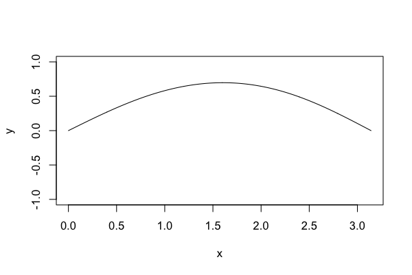

    1. Parameter set 1
    2. Parameter set 2
    3. Parameter set 3
    4. Parameter set 4
    5. Parameter set 5
    6. Parameter set 6

#### Question

38. A taught string, fixed at 2 ends, produces a harmonic series based on the [standing waves](https://en.wikipedia.org/wiki/Standing_wave#Standing_wave_on_a_string_with_two_fixed_ends) that [resonate](https://en.wikipedia.org/wiki/Resonance). Other frequencies fizzle out quickly because they are not resonant with the system.

    We will simulate a string vibrating at its [fundamental frequency](https://en.wikipedia.org/wiki/Fundamental_frequency) and two of its [overtones](https://en.wikipedia.org/wiki/Overtone). We will also pay attention to the phase of each partial.

    Let’s assume the string is of length $\pi$ meters and the period of the fundamental is $2\pi$ seconds (so $t$ goes from 0 to $2\pi$).

    $$y_1 = A_1 \sin(x)\cdot \sin(t+\phi_1)$$

    The next two overtones have similar equations.

    $$y_2 = A_2 \sin(2x)\cdot \sin(2t+\phi_2)$$

    $$y_3 = A_3 \sin(3x)\cdot \sin(3t+\phi_3)$$

    When all three modes of oscillation occur simultaneously, the result is a superposition of waves.

    $$y = y_1+y_2+y_3$$

    Determine which set of parameters generates the animation below (when viewing the superposition).

### Parameter set 1

    $$\begin{align*}
    A_1 &= 0.16 & \phi_1 &= 2.91 \\
    A_2 &= 0.42 & \phi_2 &= 0.17 \\
    A_3 &= 0.42 & \phi_3 &= 3.76 \\
    \end{align*}$$

### Parameter set 2

    $$\begin{align*}
    A_1 &= 0.17 & \phi_1 &= 6.06 \\
    A_2 &= 0.19 & \phi_2 &= 0.01 \\
    A_3 &= 0.64 & \phi_3 &= 5.21 \\
    \end{align*}$$

### Parameter set 3

    $$\begin{align*}
    A_1 &= 0.46 & \phi_1 &= 4.31 \\
    A_2 &= 0.43 & \phi_2 &= 2.02 \\
    A_3 &= 0.11 & \phi_3 &= 2.55 \\
    \end{align*}$$

### Parameter set 4

    $$\begin{align*}
    A_1 &= 0.5 & \phi_1 &= 5.03 \\
    A_2 &= 0.08 & \phi_2 &= 2.02 \\
    A_3 &= 0.42 & \phi_3 &= 3.55 \\
    \end{align*}$$

### Parameter set 5

    $$\begin{align*}
    A_1 &= 0.75 & \phi_1 &= 5.76 \\
    A_2 &= 0.14 & \phi_2 &= 0.69 \\
    A_3 &= 0.11 & \phi_3 &= 4.4 \\
    \end{align*}$$

### Parameter set 6

    $$\begin{align*}
    A_1 &= 0.11 & \phi_1 &= 6 \\
    A_2 &= 0.7 & \phi_2 &= 2.13 \\
    A_3 &= 0.19 & \phi_3 &= 5.65 \\
    \end{align*}$$

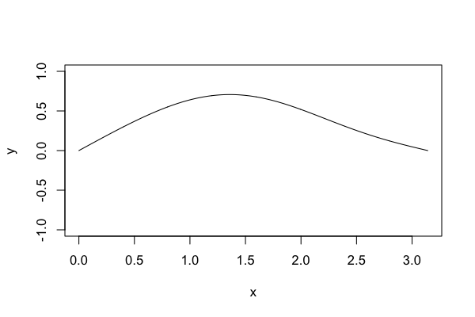

    1. Parameter set 1
    2. Parameter set 2
    3. Parameter set 3
    4. Parameter set 4
    5. Parameter set 5
    6. Parameter set 6

#### Question

39. A taught string, fixed at 2 ends, produces a harmonic series based on the [standing waves](https://en.wikipedia.org/wiki/Standing_wave#Standing_wave_on_a_string_with_two_fixed_ends) that [resonate](https://en.wikipedia.org/wiki/Resonance). Other frequencies fizzle out quickly because they are not resonant with the system.

    We will simulate a string vibrating at its [fundamental frequency](https://en.wikipedia.org/wiki/Fundamental_frequency) and two of its [overtones](https://en.wikipedia.org/wiki/Overtone). We will also pay attention to the phase of each partial.

    Let’s assume the string is of length $\pi$ meters and the period of the fundamental is $2\pi$ seconds (so $t$ goes from 0 to $2\pi$).

    $$y_1 = A_1 \sin(x)\cdot \sin(t+\phi_1)$$

    The next two overtones have similar equations.

    $$y_2 = A_2 \sin(2x)\cdot \sin(2t+\phi_2)$$

    $$y_3 = A_3 \sin(3x)\cdot \sin(3t+\phi_3)$$

    When all three modes of oscillation occur simultaneously, the result is a superposition of waves.

    $$y = y_1+y_2+y_3$$

    Determine which set of parameters generates the animation below (when viewing the superposition).

### Parameter set 1

    $$\begin{align*}
    A_1 &= 0.15 & \phi_1 &= 5.41 \\
    A_2 &= 0.69 & \phi_2 &= 5.78 \\
    A_3 &= 0.16 & \phi_3 &= 1.44 \\
    \end{align*}$$

### Parameter set 2

    $$\begin{align*}
    A_1 &= 0.67 & \phi_1 &= 0.21 \\
    A_2 &= 0.22 & \phi_2 &= 4.09 \\
    A_3 &= 0.11 & \phi_3 &= 1.38 \\
    \end{align*}$$

### Parameter set 3

    $$\begin{align*}
    A_1 &= 0.08 & \phi_1 &= 5.44 \\
    A_2 &= 0.18 & \phi_2 &= 1.82 \\
    A_3 &= 0.74 & \phi_3 &= 6.19 \\
    \end{align*}$$

### Parameter set 4

    $$\begin{align*}
    A_1 &= 0.54 & \phi_1 &= 1.82 \\
    A_2 &= 0.51 & \phi_2 &= 2.64 \\
    A_3 &= -0.05 & \phi_3 &= 5.84 \\
    \end{align*}$$

### Parameter set 5

    $$\begin{align*}
    A_1 &= 0.45 & \phi_1 &= 3.86 \\
    A_2 &= 0.14 & \phi_2 &= 5.92 \\
    A_3 &= 0.41 & \phi_3 &= 2.32 \\
    \end{align*}$$

### Parameter set 6

    $$\begin{align*}
    A_1 &= 0.09 & \phi_1 &= 4.47 \\
    A_2 &= 0.36 & \phi_2 &= 2.45 \\
    A_3 &= 0.55 & \phi_3 &= 4.05 \\
    \end{align*}$$

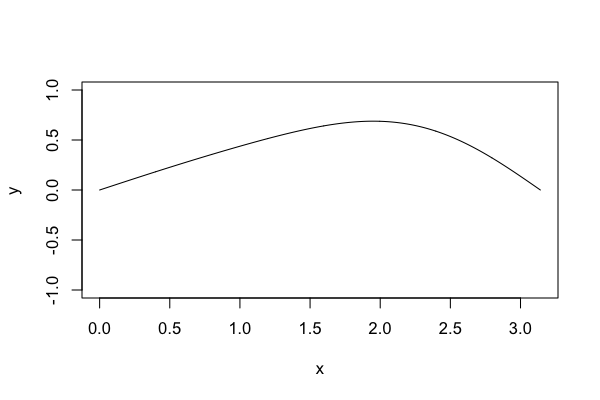

    1. Parameter set 1
    2. Parameter set 2
    3. Parameter set 3
    4. Parameter set 4
    5. Parameter set 5
    6. Parameter set 6

#### Question

40. A taught string, fixed at 2 ends, produces a harmonic series based on the [standing waves](https://en.wikipedia.org/wiki/Standing_wave#Standing_wave_on_a_string_with_two_fixed_ends) that [resonate](https://en.wikipedia.org/wiki/Resonance). Other frequencies fizzle out quickly because they are not resonant with the system.

    We will simulate a string vibrating at its [fundamental frequency](https://en.wikipedia.org/wiki/Fundamental_frequency) and two of its [overtones](https://en.wikipedia.org/wiki/Overtone). We will also pay attention to the phase of each partial.

    Let’s assume the string is of length $\pi$ meters and the period of the fundamental is $2\pi$ seconds (so $t$ goes from 0 to $2\pi$).

    $$y_1 = A_1 \sin(x)\cdot \sin(t+\phi_1)$$

    The next two overtones have similar equations.

    $$y_2 = A_2 \sin(2x)\cdot \sin(2t+\phi_2)$$

    $$y_3 = A_3 \sin(3x)\cdot \sin(3t+\phi_3)$$

    When all three modes of oscillation occur simultaneously, the result is a superposition of waves.

    $$y = y_1+y_2+y_3$$

    Determine which set of parameters generates the animation below (when viewing the superposition).

### Parameter set 1

    $$\begin{align*}
    A_1 &= 0.01 & \phi_1 &= 4.53 \\
    A_2 &= 0.47 & \phi_2 &= 3.69 \\
    A_3 &= 0.52 & \phi_3 &= 0.75 \\
    \end{align*}$$

### Parameter set 2

    $$\begin{align*}
    A_1 &= 0.38 & \phi_1 &= 5.86 \\
    A_2 &= 0.43 & \phi_2 &= 4.3 \\
    A_3 &= 0.19 & \phi_3 &= 2.35 \\
    \end{align*}$$

### Parameter set 3

    $$\begin{align*}
    A_1 &= 0.5 & \phi_1 &= 2.71 \\
    A_2 &= 0.14 & \phi_2 &= 2.06 \\
    A_3 &= 0.36 & \phi_3 &= 3.47 \\
    \end{align*}$$

### Parameter set 4

    $$\begin{align*}
    A_1 &= 0.13 & \phi_1 &= 5.85 \\
    A_2 &= 0.07 & \phi_2 &= 3.03 \\
    A_3 &= 0.8 & \phi_3 &= 0.34 \\
    \end{align*}$$

### Parameter set 5

    $$\begin{align*}
    A_1 &= 0.64 & \phi_1 &= 1.25 \\
    A_2 &= 0.2 & \phi_2 &= 4.9 \\
    A_3 &= 0.16 & \phi_3 &= 2.1 \\
    \end{align*}$$

### Parameter set 6

    $$\begin{align*}
    A_1 &= 0.15 & \phi_1 &= 3.94 \\
    A_2 &= 0.67 & \phi_2 &= 1.34 \\
    A_3 &= 0.18 & \phi_3 &= 0.5 \\
    \end{align*}$$

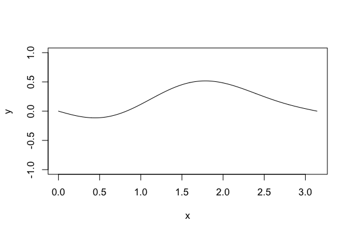

    1. Parameter set 1
    2. Parameter set 2
    3. Parameter set 3
    4. Parameter set 4
    5. Parameter set 5
    6. Parameter set 6